# 01 - Introducción

François Rebaudo, IRD francois.rebaudo@ird.fr

Marzo 2019 ; PUCE-Quito-Ecuador http://myrbooksp.netlify.com/ CC BY-NC-ND 3.0

[figure not shown]

[figure not shown]

# ¿Porque utilizar R?

## 1. R es gratis y libre

- Libertad de ejecutar el programa como se desea
- Libertad de acceder al código fuente, y cambiarlo
- Libertad de redistribuir copias (redistribución)
- Libertad de distribuir copias de sus versiones modificadas

## 2. R funciona con los principales sistemas operativos

- Linux
- Mac OSX
- Windows

## 3. R es un programa indispensable en ciencia

- Manejar conjunto de datos y *Big Data*
- Analizar datos
- Hacer estadísticas
- Automatizar el procesamiento de la información en *High Performance Computer Clusters*
- …también hay Python

## 4. R tiene una comunidad muy activa

- ‘#rstats’ hashtag https://twitter.com/search?q=%23rstats
- Rweekly https://rweekly.org/
- R-bloggers https://www.r-bloggers.com/
- Stack Overflow https://stackoverflow.com/

pero también:

- R Conferences https://jumpingrivers.github.io/meetingsR/events.html
- Github https://github.com

ver https://blog.revolutionanalytics.com/2017/06/r-community.html

## 5. R tiene una comunidad que contribuye a su desarrollo

- Hay mas de 10 000 paquetes R
- R tiene mas de 20 años
- R está bien soportado (nuevas versiones frecuentes)

## 6. R integra las últimas tecnologías de la información

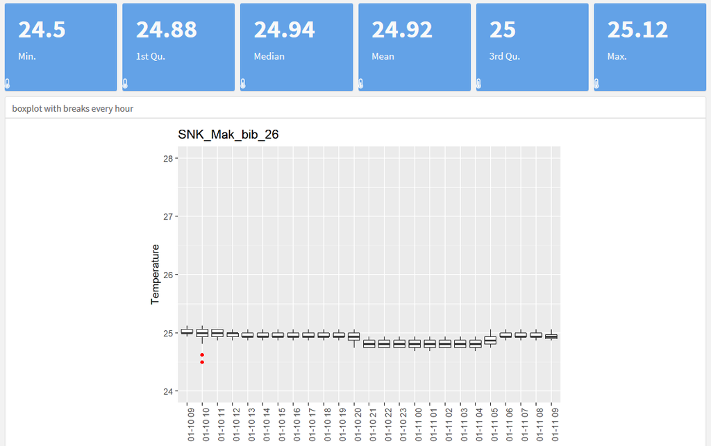

# Objetivos del curso

## Aprender sobre los conceptos básicos de R

- Tipos de datos
- El concepto de objeto
- Los scripts
- Las funciones
- Documentación
- Importar y exportar datos
- Algorítmico

## Tener un entorno de desarrollo eficiente

- Conocer las opciones de editores de texto
- Organizar su espacio de trabajo
- Gestionar versiones
- Documentar

## Comunicar sus resultados

- Introducción a los gráficos
- Gráficos para publicar artículos
- Ejemplos de pruebas estadísticas
- Reproductibilidad de los resultados científicos
- Hacer reportes con Rmarkdown

## … y practicar para ser autónomos en sus futuros proyectos

# Abrir R

## Consola con Windows

[figure not shown]

# ¡Podemos empezar!

# 01 - Introducción

François Rebaudo, IRD francois.rebaudo@ird.fr

Marzo 2019 ; PUCE-Quito-Ecuador http://myrbooksp.netlify.com/

[figure not shown]

[figure not shown]

# ¿Porque utilizar R?

## 1. R es gratis y libre

- Libertad de ejecutar el programa como se desea
- Libertad de acceder al código fuente, y cambiarlo
- Libertad de redistribuir copias (redistribución)
- Libertad de distribuir copias de sus versiones modificadas

## 2. R funciona con los principales sistemas operativos

- Linux
- Mac OSX
- Windows

## 3. R es un programa indispensable en ciencia

- Manejar conjunto de datos y *Big Data*
- Analizar datos
- Hacer estadísticas
- Automatizar el procesamiento de la información en *High Performance Computer Clusters*
- …también hay Python

## 4. R tiene una comunidad muy activa

- ‘#rstats’ hashtag https://twitter.com/search?q=%23rstats
- Rweekly https://rweekly.org/
- R-bloggers https://www.r-bloggers.com/
- Stack Overflow https://stackoverflow.com/

pero también:

- R Conferences https://jumpingrivers.github.io/meetingsR/events.html
- Github https://github.com

ver https://blog.revolutionanalytics.com/2017/06/r-community.html

## 5. R tiene una comunidad que contribuye a su desarrollo

- Hay mas de 10 000 paquetes R
- R tiene mas de 20 años
- R está bien soportado (nuevas versiones frecuentes)

## 6. R integra las últimas tecnologías de la información

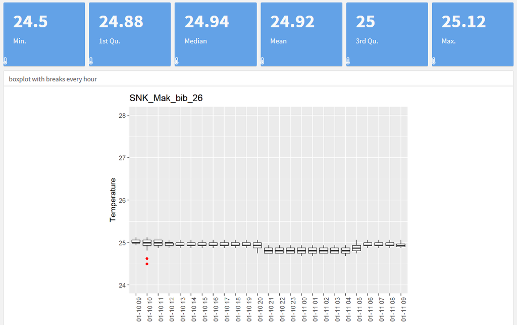

# Objetivos del curso

## Aprender sobre los conceptos básicos de R

- Tipos de datos
- El concepto de objeto
- Los scripts
- Las funciones
- Documentación
- Importar y exportar datos
- Algorítmico

## Tener un entorno de desarrollo eficiente

- Conocer las opciones de editores de texto
- Organizar su espacio de trabajo
- Gestionar versiones
- Documentar

## Comunicar sus resultados

- Introducción a los gráficos
- Gráficos para publicar artículos
- Ejemplos de pruebas estadísticas
- Reproductibilidad de los resultados científicos
- Hacer reportes con Rmarkdown

## … y practicar para ser autónomos en sus futuros proyectos

# Abrir R

## Consola con Windows

[figure not shown]

# ¡Podemos empezar!